# Basic spatial analysis of customers dataset

In this notebook basic exploratory analysis of spatial distribution of the dataset is presented. First, basic data cleaning:

```r
library(readr)
library(tidyverse)
library("leaflet")
library(sf)
library(tmap)

geolocation <- read_csv("data/olist_geolocation_dataset.csv")
```

Removal of the points outside the bounding box:

```r
#Brazils most Northern spot is at 5 deg 16′ 27.8″ N latitude.;
geolocation = geolocation[geolocation$geolocation_lat <= 5.27438888,]
#it’s most Western spot is at 73 deg, 58′ 58.19″W Long.
geolocation = geolocation[geolocation$geolocation_lng >= -73.98283055,]
#It’s most southern spot is at 33 deg, 45′ 04.21″ S Latitude.
geolocation = geolocation[geolocation$geolocation_lat >= -33.75116944,]
#It’s most Eastern spot is 34 deg, 47′ 35.33″ W Long.
geolocation = geolocation[geolocation$geolocation_lng <=  -34.79314722,]
```

Create variables for different levels of aggregation. In zip code, every digit added gives bigger detail. There are 5 digits (levels of aggregation) present, but for summary data (and not individual customers) 3rd level of aggregation is the lowest possible to obtain sensible groupings of customers.

```r
geolocation$zip_code_1 <- str_sub(geolocation$geolocation_zip_code_prefix, 1, 1)
geolocation$zip_code_2 <- str_sub(geolocation$geolocation_zip_code_prefix, 1, 2)
geolocation$zip_code_3 <- str_sub(geolocation$geolocation_zip_code_prefix, 1, 3)

geolocation %>%
  group_by(geolocation_zip_code_prefix) %>%
  tally() %>%
  arrange(-n) -> no_of_coords_per_prefix

no_of_coords_per_prefix %>% summary()
```

```
##  geolocation_zip_code_prefix       n
##  Length:19010                Min.   :   1.00
##  Class :character            1st Qu.:  10.00
##  Mode  :character            Median :  29.00
##                              Mean   :  52.61
##                              3rd Qu.:  67.00
##                              Max.   :1146.00
```

Most of the zip codes have more than one geolocation assigned. It is sensible to select the most central point. PAM clustering with one center can be used to achieve that. For every zip code, algorithm is run and cluster center is saved as a proper zip code location. This takes a long time, so the results are cached.

```r
no_of_coords_per_prefix %>%
  filter(n != 1) %>%
  .$geolocation_zip_code_prefix -> prefixes_with_more_coords

library(cluster)

robust_pam <- function(initial_df) {

  message(initial_df$geolocation_zip_code_prefix[1])

  if (nrow(initial_df) == 1){
    return(initial_df)
  }

  coords <- initial_df %>%
    select(geolocation_lat, geolocation_lng)

  pam1 <- pam(coords, 1)

  out <- initial_df[pam1$id.med, ]

  out
}

geolocation %>%
  mutate(to_group = geolocation_zip_code_prefix) %>%
  group_by(to_group) %>%
  nest() -> grouped

# results cached - very resource expensive
# grouped %>%
#   mutate(sampled = map(data, robust_pam)) -> res
# sampled_zipcodes <- bind_rows(res$sampled)
# save(sampled_zipcodes, file = 'data/map_sampled_zipcodes.Rdata')


load('data/map_sampled_zipcodes.Rdata')
```

Next, we can obtain contour map of Brazil using brazilmaps package. Other maps, like microregions are also present there. This package is avaliable only from cran archive to install locally - it was removed from official cran repo.

```r
brazil_map <- brazilmaps::get_brmap("Brazil")
# m_2 <- brazilmaps::get_brmap("MicroRegion")

df <- sf::st_as_sf(sampled_zipcodes, coords = c(3,2))
```

```r
df_small <- df %>% sample_frac(1)
```

Basic map of zipcodes - places in which customers placed orders

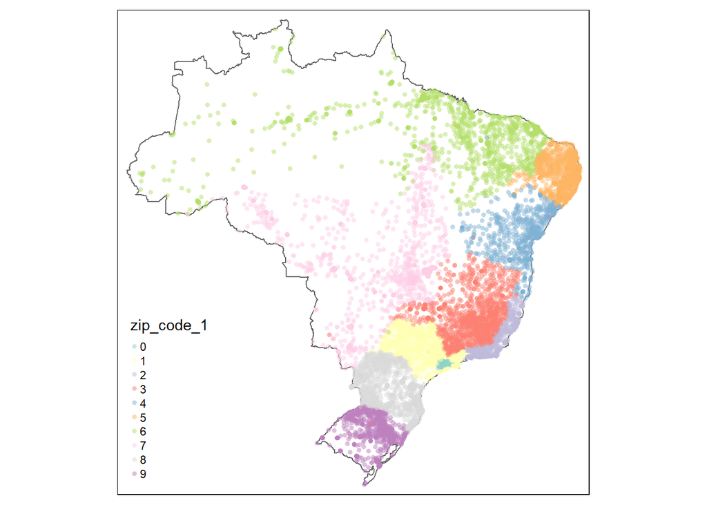

```r
# tmap_mode("view")
tmap_mode("plot")

tm_shape(brazil_map) +
  tm_polygons(col = "white") +
  tm_shape(df_small) +
  tm_symbols(size = 0.1,
             col = "zip_code_1",
             border.lwd = NA,
             alpha = 0.5)
```

Adding information about orders:

```r
orders <- read_csv("data/olist_orders_dataset.csv")
customers <- read_csv("data/olist_customers_dataset.csv")
```

Number of orders per zip code:

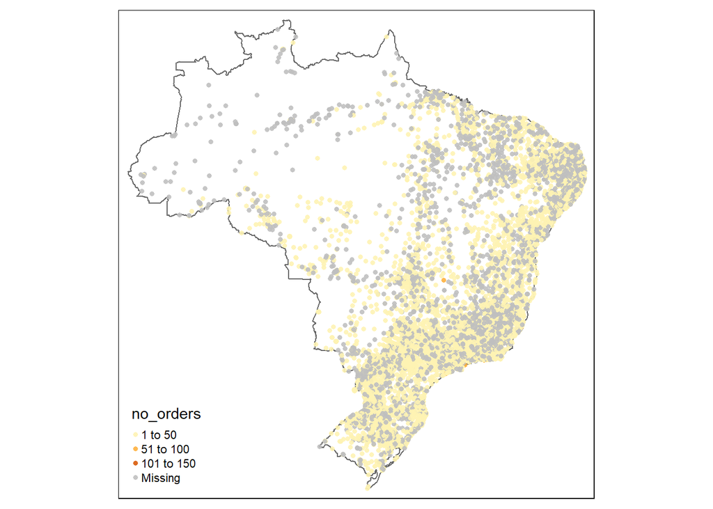

```r
orders %>%
  left_join(
customers %>%
  select(1, 3)
) -> orders_with_zip

orders_with_zip %>%
  group_by(customer_zip_code_prefix) %>%
  tally() %>%
  rename(no_orders = n) -> no_orders_per_zip

df %>%
  left_join(no_orders_per_zip,
            by = c("geolocation_zip_code_prefix" = "customer_zip_code_prefix")) -> temp


tm_shape(brazil_map) +
  tm_polygons(col = "white") +
  tm_shape(temp) +
  tm_symbols(
    # size = "no_orders",
             col = "no_orders",
             n = 5,
             border.lwd = NA,
             size = 0.1,
             alpha = 0.9)
```

For some of the zipcodes there is not even one order placed. This database has full range of zipcodes - even if there are no customers in particular area. Number of orders per zip code (second level of aggregation):

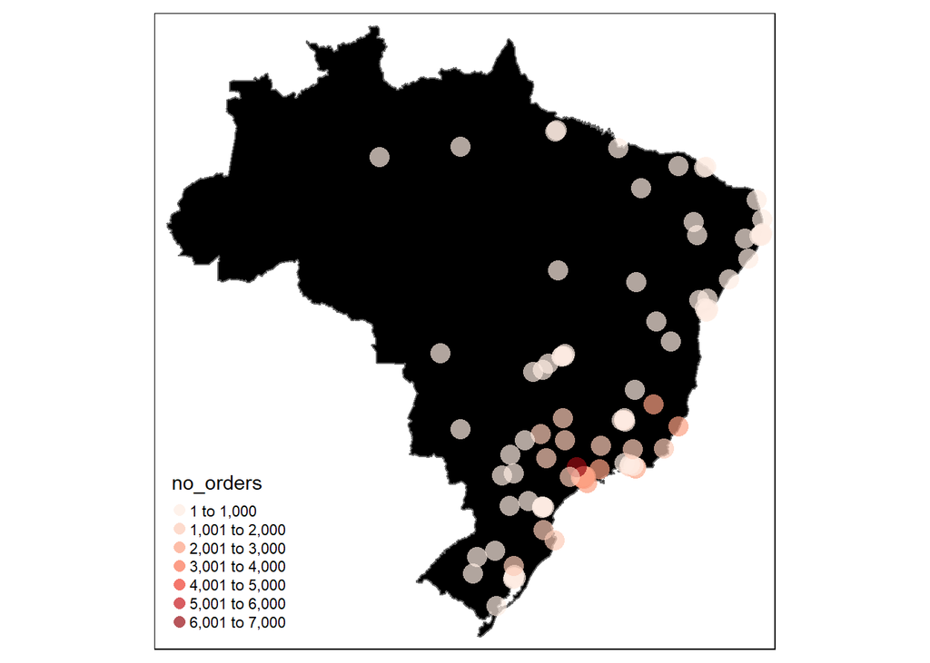

```r
no_orders_per_zip_2 <- no_orders_per_zip %>%
  mutate(zip_code_2 = str_sub(customer_zip_code_prefix, 1, 2)) %>%
  group_by(zip_code_2) %>%
  summarise(no_orders = sum(no_orders, na.rm = T))

df %>%
  left_join(no_orders_per_zip_2) %>%
  group_by(zip_code_2) %>%
  filter(row_number()==1) %>%
  ungroup()-> temp1


tm_shape(brazil_map) +
  tm_polygons(col = "black") +
  tm_shape(temp1) +
  tm_symbols(
    # size = "no_orders",
    col = "no_orders",
    # n = 5,
    border.lwd = NA,
    palette = "Reds",
    size = 1,
    alpha = 0.7)
```

Number of orders per zip code (third level of aggregation):

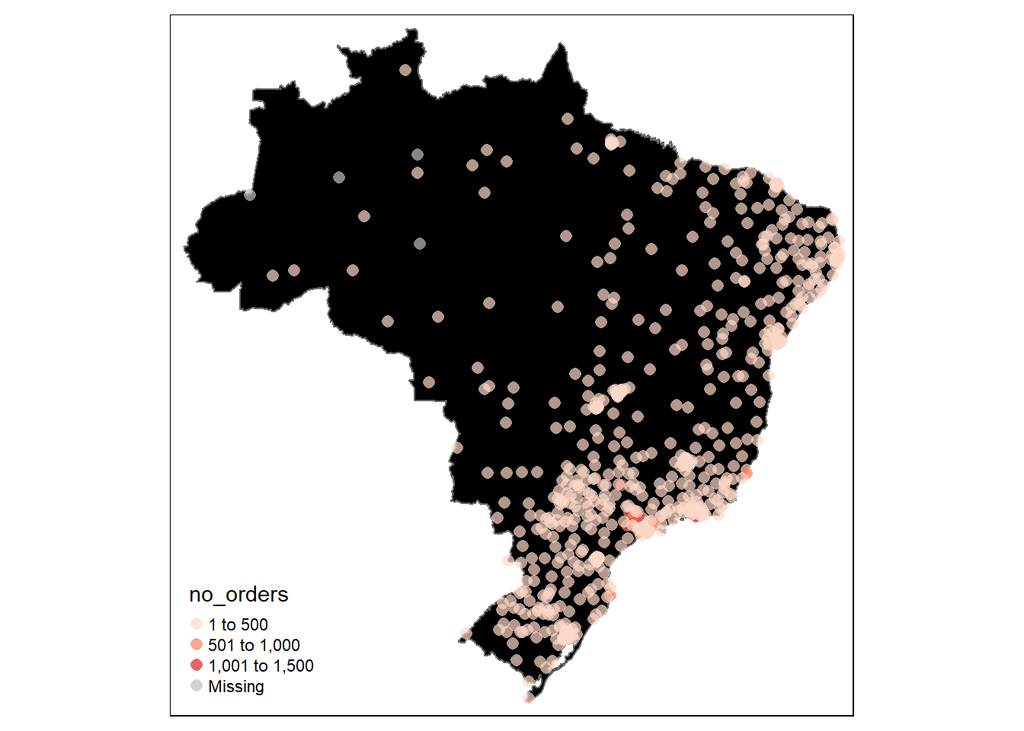

```r
no_orders_per_zip_3 <- no_orders_per_zip %>%
  mutate(zip_code_3 = str_sub(customer_zip_code_prefix, 1, 3)) %>%
  group_by(zip_code_3) %>%
  summarise(no_orders = sum(no_orders, na.rm = T))

df %>%
  left_join(no_orders_per_zip_3) %>%
  group_by(zip_code_3) %>%
  filter(row_number()==1) %>%
  ungroup()-> temp2


tm_shape(brazil_map) +
  tm_polygons(col = "black") +
  tm_shape(temp2) +
  tm_symbols(
    # size = "no_orders",
    col = "no_orders",
    # n = 5,
    border.lwd = NA,
    palette = "Reds",
    size = 0.3,
    alpha = 0.7)
```

Bigger concentration of orders is visible in southern part of Brazil - this is more urban area. Joinig information about loyal customers - from other notebook. After that, plotting loyal customers on the map to check spatial distribution.

```r
orders_loyal <- new.env()
load(file ='data/05_orders_enhanced.Rdata', env = orders_loyal)
orders_master <- orders_loyal$orders_master
first_orders <- orders_loyal$first_orders

df %>%
  left_join(first_orders,
            by =c('geolocation_zip_code_prefix'='customer_zip_code_prefix')) -> temp_customer

pal <- colorFactor(c("navy", "red"), domain = c("0", "1"))

leaflet(temp_customer %>% filter(if_second_order=='1')) %>%
  addTiles() %>%
  addCircleMarkers(
    radius = ~ifelse(if_second_order == "0", 0.1, 2),
    color = ~pal(if_second_order),
    stroke = FALSE, fillOpacity = 0.5
  )
```

[interactive chart not shown]

It looks like the spatial distribution of customers placing second order is more or less the same as other customers.